# Python Foundations Project: Austo

Two key observations here;

1) Post-gradutes make more money, and are more likely to buy the more expensive models of cars.

2) It appears that buyers Age 35-45 are more likely to buy the more expensive SUVs if they make less than their peers the same age. Are these buyers with more dependents?

```python
df.middleage = df.loc[(df.Age > 35) & (df.Age < 45)]
df.middleage.groupby(by = ['No_of_Dependents','Make']).size()
```

```
No_of_Dependents  Make
0                 SUV        2
1                 Sedan    108
2                 SUV       23
                  Sedan    123
3                 SUV       31
4                 SUV       18
dtype: int64
```

Yes - that is the bottom grouping of orange SUV buyers in the 35 to 45 year old range. This is a niche SUV buyer profile:

- Age 35-45
- 3+ Dependents
- Make less than their professional peers

We saw earlier that number of dependents did affect salary; but it does determine buying behavior. These families will spend more on an SUV - though why not a Hatchback I can not guess.

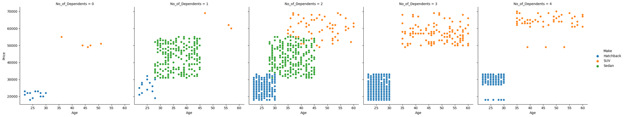

```python
#Make and Price are heavily correlated, but what makes a particular aged person spend more on the same make?
#ex; What makes a given 25 year old buy the 32k Hatchback instead of the 18K Hatchback?
sns.relplot(data=df, x="Age", y="Price", hue="Make", col = "No_of_Dependents")
```

While it is true that Hathback buyers with 4 dependents nearly explusively will buy expensive Hatchbacks, they are not the only ones that will. All other categorical variables were tested this way with no other notable patterns. Here is one more example below; not that while Salaried workers are still buying SUVs, they are not buying more expensive SUVs than their Buisness counterparts.

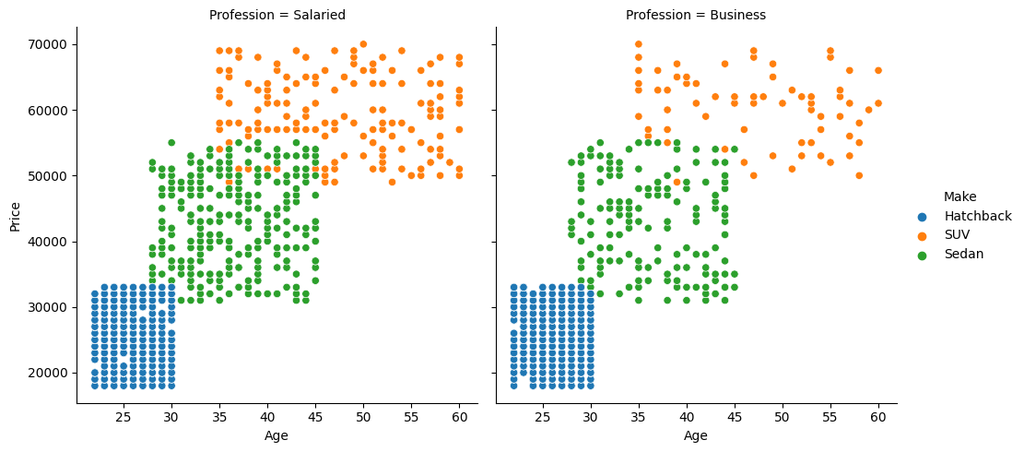

```python
sns.relplot(data=df, x="Age", y="Price", hue="Make", col = "Profession")
```

We saw earlier that Price and Salary were gently correlated; lets pull another visualization.

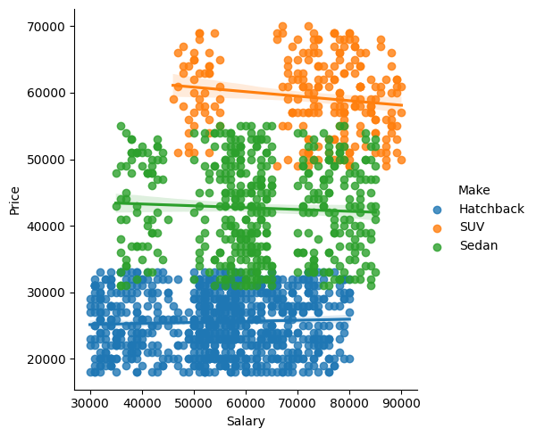

```python
sns.lmplot(data = df, x = 'Salary', y = 'Price', hue='Make')
```

If you consider all data points; yes as Salary increases there is a general upward trend in price of car. However, as we continue to see that has more to do with the Make of the care. Within a Make category, there is a near uniform distribution of Price and Salary - this is not what is empowering buyers to spend more. Unfortunately I do not see a pattern in decision making, for example, a 22 year old to buy the 18k Hatchback vs the 32k Hatchback.

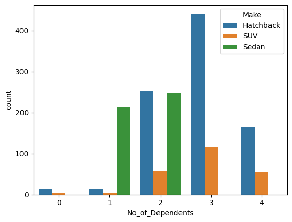

```python
#Hatchback buyers come from all salaries, but younger buyers. Does that match our understanding that younger buyers have more dependents?
sns.countplot(data = df, x ="No_of_Dependents", hue = "Make")
```

Hatchback buyers have 2+ dependents, Sedan buyers have 1-2 dependents, and SUV buyers are most common in the 3-4 dependents categories.

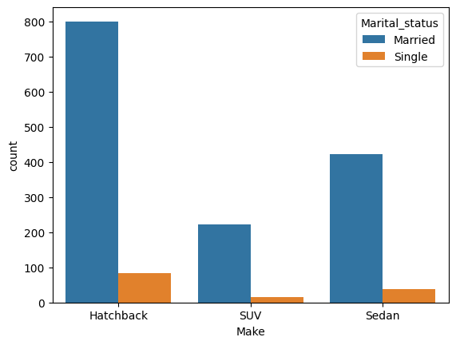

```python
#The vast majority of our data set has Dependents. Does being single affect buying decision?
sns.countplot(data = df, x ="Make", hue = "Marital_status")
```

Not at all - the relative shapes of these are similar.

#### Question 10: For customers who have 3 or fewer dependents, how does the average car price vary by profession ? [2 marks]

```python
#new dataframe, only buyers with 3 or fewer dependents
df.less_depend = df.loc[df['No_of_Dependents'] < 4]
#then group on profession and find average price of vehicle purchase
df.less_depend.groupby(by = ['Profession'])['Price'].mean()
```

```
Profession
Business    32830.220713
Salaried    37036.175711
Name: Price, dtype: float64
```

```python
#Are Salaried workers buying nicer versions of the same make?
df.less_depend.groupby(by = ['Profession', 'Make'])['Price'].mean()
```

```
Profession  Make
Business    Hatchback    24664.850136
            SUV          58803.921569
            Sedan        42608.187135
Salaried    Hatchback    24708.215297
            SUV          57583.333333
            Sedan        42709.342561
Name: Price, dtype: float64
```

```python
#Of are they buying more of the more expensive make of cars?
df.less_depend.groupby(by = ['Profession', 'Make'])['Price'].count()
```

```
Profession  Make
Business    Hatchback    367
            SUV           51
            Sedan        171
Salaried    Hatchback    353
            SUV          132
            Sedan        289
Name: Price, dtype: int64
```

#### Question 11: For customers who have availed a home loan and a personal loan, how does the price vary by profession? [3 marks]

```python
#create new dataframe of buyers who like using credit
df.credit_users = df.loc[(df.Personal_loan == "Yes") & (df.House_loan == "Yes")]
#same as above, find the average price of car purchase
df.credit_users.groupby(by = ['Profession'])['Price'].mean()
```

```
Profession
Business    30472.868217
Salaried    32463.087248
Name: Price, dtype: float64
```

```python
#Are they buying more expensive vehicles within a make category?
df.credit_users.groupby(by = ['Profession', 'Make'])['Price'].mean()
```

```
Profession  Make
Business    Hatchback    25548.387097
            Sedan        43194.444444
Salaried    Hatchback    25722.222222
            Sedan        42745.762712
Name: Price, dtype: float64
```

```python
#Or just buying proportionally more of the expensive vehicles?
df.credit_users.groupby(by = ['Profession', 'Make'])['Price'].count()
```

```
Profession  Make
Business    Hatchback    93
            Sedan        36
Salaried    Hatchback    90
            Sedan        59
Name: Price, dtype: int64
```

#### Observations:

Again we see that the Salaried buyers spend more money by buying more expensive vehicle types (as opposed to more expensive versions of the same types). This spending is only 2k more, on average.

## Conclusion and Recommendations

#### **Question 12:** Write the conclusions and business recommendations derived from the analysis. (6 marks)

### **Conclusions**

As Austo considers enter the US car market, they should aim to choose or adapt a current product from their fleet that is a family-friendly vehicle that can be marketed to one of the below profiles.

### **Buyer Profiles**

> Hatchback Buyer Profile (18k - 33k)

These buyers are aged 22-32 and generally have 2+ dependents. They are likely buying a vehicle that is safe, easy to install car seats, or has otherwise has utility for their larger, younger families.

> SUV, Type 1 Buyer Profile (49k-70k)

These buyers are aged 35-45, have 3 or more dependents. (Incidentally, they also make less than their peers in their profession, and do not have house loans) While most buyers in this age demographic have 1-2 dependents, and thus belong to the Sedan Buyer Profile, this is a small but mighty buying group. Their buying decision for the move expensive SUV is likely due to necessary space to fit the larger, older family.

> SUV, Type 2 Buyer Profile (49k-70k)

These buyers are aged 45-60 and have 2+ dependents. More collaboration with data team required to explain why SUVs for this demographic.

### **Recommendations for further data exploration and analysis**

Considering pricing has to be the next greatest hurdle. This dataset did not propose a reason why buyers would participate in the bottom vs the top of the price range for their vehicle type. Is this something about the car - brand, safety features, electric vs gasoline? Or something about the demographic not included in the data set - city, credit score?

Expand data to include consideration of target markets; given the current demographics - look for mid size cities with large suburb and less rural surrondings. This requires its own analysis, but this particual american "consultant" suggests mid-size cities of North Carolina, Texas, and Arizona.

Expand data to include manufactorers, so analysis can be run on competitors. Is Austo - the company we are considering - more like BMW (high budget, over quarter million sales in USA) or Fiat (low budget, less than 10k sales in USA)? Do these profiles hold up when considering competitor data? Does it make more sense to enter a city with or without competitor dealerships?

Current data is only considering middle class, educated americans with dependents, mostly early career. Is this the demographic of Austo buyers in their European markets? If not - consider matching demographics closer to buyers in European markets. The US market has many buyers outside the rather narrow scope of this data set.

The scope of this project only considers buyer profiles - but next steps in considering the buyer's decision making could also include:

- Maintanence costs research: Are the parts and labor costs for these european cars accessible, affordable for the targeted buyers? If not, will dealerships have a loaner program (like some of their competitors?).
- Dealership or Showroom: Are potential buyers traveling to a big city dealership and driving away with their car today, or will the cars be presented ona showroom floor and ordered?
- In house financing: since half the buyers are using personal loans, does Austro have the capacity to offer competitive financing as part of their sales deal?